# Threshold Experiment

Kevin Hu

March 28, 2018

## Introduction

We want to better understand the impact of the threshold for our network detection in PINTs on the success of that network detection. As I understand, the profit/cost of each node is the log-difference between the node’s significance and the threshold value. Thus, the relative significance of each node is considered in the profit/cost graph. PINTS implements the fast heinz algorithm to find a maximal subnet. I need to read this a bit more.

The hope is to determine, in light of that, an optimal threshold to use for subnet detection. Ideally, this would allow us to implicate new genes that are at the border of significance and non-significance.

## Required Files

- mut_data.txt
- control_summary_10k.txt, or another source of control mutation counts.
- genes_of_interest.txt, or another source of possible disease genes.
- threshold_list.txt, a column of threshold values to be tested.

## Required Packages

- BioNet - For manipulating InWeb, I thnk.
- igraph - To manipulate graphs.
- graph - Some more base graph functions
- PINTS - That’s the whole point of this project. Install from Github.
- gtools - Don’t actually remember what this is for, but I think one of my population simulations functions depends on it.
- HighSpeedStats - Has a fast implementation of Fisher’s exact test for large numbers.

## Methods

We’ll use the method done in Test_Run.Rmd to test subnet-detection at each chosen threshold level.

This will be run several times for each threshold value.

We will measure performance by taking the following statistics for each threshold:

- Sensitivity - percent of true genes that are detected.
- Specificity - percent of detected negatives that are true negatives.
- False Discovery Rate - Type 1 errors, so percent of detected positives that are false discoveries
- Edge-Connectivity - The minimum number of edges that need to be removed in order to disconnect the graph (This might not be a good measure of connectivity)
- Average Degree - Average degree of each gene within the subnetwork (ignoring edges to non-detected genes)
- percent of signal (weighted by signal) (how do we do this? what does % of signal mean?)

## Threshold values

We’ll use as a baseline the Bonferroni-corrected threshold for $\alpha = 0.05$, which is $\alpha_B = 5 \times 10^{-6}$. From there, we’ll vary $ln(\alpha_B)$ in increments of $0.5$, up to a difference of $\pm 10$. For each threshold value, we’ll run 50 trials… or I guess we could do way more if I put it onto the clusters. We’ll ask Chris and see how he feels.

## Experimental Setup

We’ve already loaded all the code for the de novo simulator, now we need to run the setup for PINTS.

```r
PPINetPath <- system.file("extdata", "InWeb3_HC_PPI_comp0.net", package="PINTS")
PPIAnnotPath <- system.file("extdata", "InWeb3_HC_PPI_comp0_geneAnnotation.txt", package="PINTS")
PPI <- loadPPINetwork(PPINetPath, PPIAnnotPath)
```

```
## PPI Network loaded with igraph pajek format with nodeAnnot:
##
##       g : igraph (pajek)
##
##       nodeAnnot : geneAnnotation (Ensemble, HUGO, Genomic position etc.)
##
```

```r
network <- PPI$g #our network file
nodeAnnot <- PPI$nodeAnnot #data frame of node annotations

geneScorePath <- system.file("extdata", "InWeb3_HC_PPI_Evolution_pvals.txt", package="PINTS")
nodeWeightTable <- read.table(geneScorePath, head=T, stringsAsFactors=F)
#gene expression data
geneExpressionPath <- system.file("extdata", "Binary_Pref_Gene_Exp_Roadmap.txt", package="PINTS")
gExpData <- read.table(geneExpressionPath, head=T, stringsAsFactors=F)
#And this tells us which genes are actually expressed in the tissues of interest.
genes <- gExpData[,"Ensemble"]

walking <- function(network, steps, startGene){
  walk <- random_walk(network, start = startGene, steps)

  while(any(table(walk) > 1)){
      walk <- random_walk(network, start = startGene, steps)
  }

  return(walk)
}
```

### One Run

```r
set.seed(1234)
# Number of disease genes
nSubnet <- 10
# Number of patients in case group
n <- 100
# Base Threshold
thresh <- 3e-8

nGenes <- length(nodeAnnot[[3]])
startNode <- sample(1:nGenes, 1)
startGenes <- nodeAnnot[startNode, c('Ensemble')]

subnet <- walking(network, nSubnet, startGenes)
print(subnet)
```

```
## + 10/12687 vertices, named, from 77c4934:
##  [1] ENSG00000103415 ENSG00000182185 ENSG00000163430 ENSG00000100253
##  [5] ENSG00000003393 ENSG00000156113 ENSG00000170515 ENSG00000198569
##  [9] ENSG00000167552 ENSG00000196084
```

```r
candidate_genes <- as.data.frame(attributes(subnet)$names)
colnames(candidate_genes) <- "Ensembl"

# Double-check this portion here. Why are these frequencies uniformly distributed?
candidate_genes$freq <- runif(nrow(candidate_genes))

results <- data.frame(gene = gene_list$Ensembl, pvals = rep(1, nrow(gene_list)))

population <- Gen_pop(n, 1, 0.38)[1:n,]
population <- Initiate_population(population, gene_list$Ensembl)
population <- Cohort_mut(population,
                 gene_list$Ensembl,
                 gene_list$freq,
                 candidate_genes$Ensembl,
                 candidate_genes$freq)
cases <- colSums(population)

for(q in 1:nrow(gene_list)){
    results$pvals[q] <- big_fish(gene_list[q,1], cases, control_agg)
}

for(i in 1:nrow(nodeWeightTable)) {
  nodeWeightTable[i,"pvalues"] <- results[i,"pvals"]
}

#Our simulated disease network with prepicked subnet.
diseaseNetwork <- buildDiseaseNetwork(network, nodeWeightTable, nodeAnnot, nodeNameBy ="Ensemble", nodeSelected=genes)
```

```
## Ensemble names are sorted in the order of InWeb gene.
```

```r
set.seed(1234)
nNull <- 100 #the number of null top subnetwork
nullDiseaseNetwork <- randDiseaseNetwork(diseaseNetwork, nPermute=nNull)
```

```
## Non Degree preserving random permutation
```

```r
print(nullDiseaseNetwork[1:10,1:12])
```

```
##       Ensemble          pvalues null1  null2  null3  null4  null5  null6
##  [1,] "ENSG00000127720" "1"     "1107" "6809" "1581" "3803" "9716" "2995"
##  [2,] "ENSG00000109819" "1"     "6054" "2299" "8836" "1875" "195"  "1544"
##  [3,] "ENSG00000161057" "1"     "5927" "6167" "3963" "7074" "8442" "4127"
##  [4,] "ENSG00000189241" "1"     "6063" "3723" "4767" "7760" "4157" "4010"
##  [5,] "ENSG00000182511" "1"     "8373" "9453" "1500" "2075" "5910" "33"
##  [6,] "ENSG00000100796" "1"     "6227" "2650" "7310" "8217" "7735" "3650"
##  [7,] "ENSG00000135541" "1"     "93"   "6625" "7693" "5962" "4290" "6815"
##  [8,] "ENSG00000143376" "1"     "2261" "3430" "1761" "906"  "6066" "8416"
##  [9,] "ENSG00000180739" "1"     "6476" "7524" "253"  "6215" "2329" "451"
## [10,] "ENSG00000172172" "1"     "4999" "2925" "3709" "6466" "4807" "1538"
##       null7  null8  null9  null10
##  [1,] "7175" "5634" "5905" "4900"
##  [2,] "1202" "3296" "5123" "6867"
##  [3,] "5120" "7193" "5093" "7575"
##  [4,] "3441" "1535" "5437" "811"
##  [5,] "6414" "4764" "1898" "2152"
##  [6,] "3684" "2796" "7597" "7580"
##  [7,] "7813" "9241" "3428" "3077"
##  [8,] "3527" "7518" "1261" "6077"
##  [9,] "409"  "8905" "6122" "3253"
## [10,] "2731" "942"  "6905" "3240"
```

```r
result <- runDiseaseSubnetSearch(diseaseNetwork, nodeAnnot, sigThres= thresh, nullDiseaseNetwork, showResult=TRUE)
```

```
##  run disease-associated subnetwork search
##  NULL
## The subnet nodes ENSG00000156113 ENSG00000103415 ENSG00000003393 ENSG00000100253 ENSG00000182185 ENSG00000096384 ENSG00000101266 ENSG00000167552
## The score of nodes 25.92958 82.55967 33.41439 37.16405 3.587428 -7.522879 -7.522879 11.01649
## The score sum of all nodes 178.6258
## The score sum of signal nodes 6
## The score sum of null nodes 2
## It returns the list of the detected subnets:
##
##       subnetList[[1]] corresponds to top scoring subnet
##
##       subnetList[[2:]] the null top scoring subnets.
##
```

```r
subnetNodes <- result[[1]]

subnetNodesHUGO <- nodeAnnot[ which(nodeAnnot[,"Ensemble"] %in% subnetNodes), "HUGO"]
topSubnet <- induced.subgraph(diseaseNetwork, subnetNodes)
is.connected(topSubnet)
```

```
## [1] TRUE
```

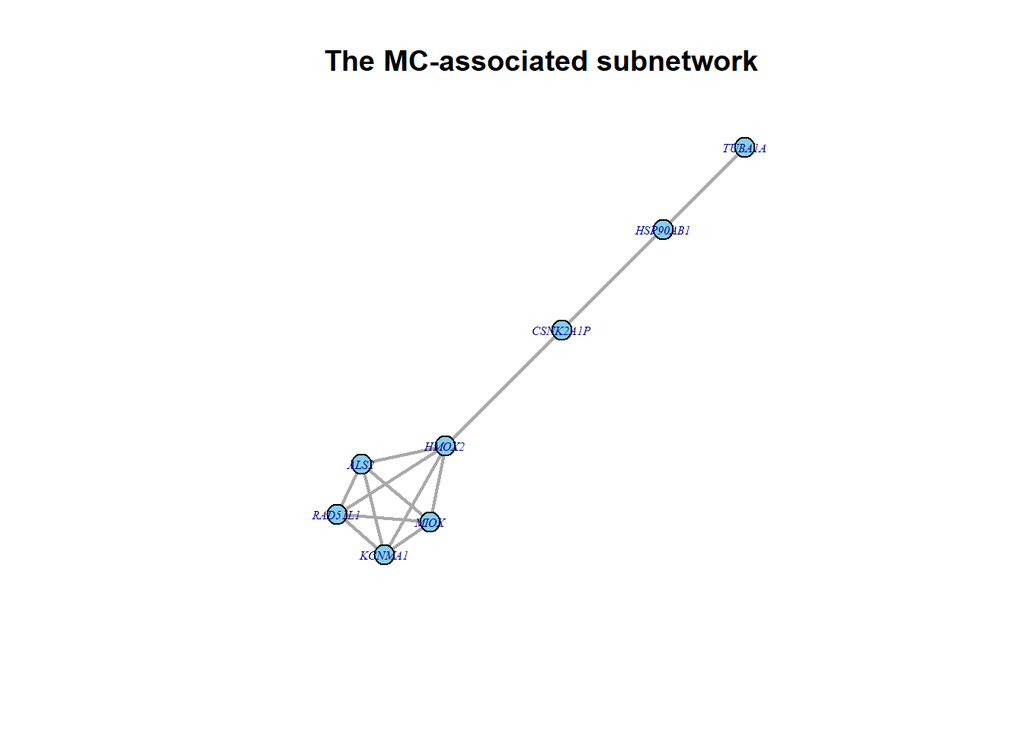

```r
topSubnet.layout <- layout.fruchterman.reingold(topSubnet)
plot(topSubnet, layout = topSubnet.layout, main= "The MC-associated subnetwork", vertex.color="skyblue", vertex.size= 10, vertex.label=subnetNodesHUGO, vertex.label.font=3, vertex.label.cex=0.5, edge.width=2)
```

### Results

```r
test.validity <- data.frame(Stat = c("Sensitivity", "Specificity", "FDR", "Edge-Con"), Value = NA)

# Compute Sensitivity - True Positive Rate (Power)
check <- rep(0, length(candidate_genes$Ensembl))
for(i in 1:length(check)){
  check[i] <- any(result[[1]] == candidate_genes$Ensembl[i])
}

test.validity[test.validity$Stat == "Sensitivity", 2] <- sum(check) / length(check)
test.validity[test.validity$Stat == "FDR", 2] <- 1-test.validity[1,2]

# Compute Specificity - True Negative Rate
true_negs <- nGenes - 2*length(candidate_genes$Ensembl) +sum(check)
test.validity[test.validity$Stat == "Specificity", 2] <- true_negs/nGenes

# Compute edge-connectivity - minimum number of edges to remove to disconnect the graph
test.validity[test.validity$Stat == "Edge-Con", 2] <- edge_connectivity(topSubnet)

kable(test.validity)
```

| Stat | Value |
| --- | --- |
| Sensitivity | 0.6000000 |
| Specificity | 0.9988965 |
| FDR | 0.4000000 |
| Edge-Con | 1.0000000 |

## Actual Experimental Script

Below is the script, not evaluated in this file, which we can submit to the clusters for this experiment.

```r
# Include all the code in the setup to this document.

PPINetPath <- system.file("extdata", "InWeb3_HC_PPI_comp0.net", package="PINTS")
PPIAnnotPath <- system.file("extdata", "InWeb3_HC_PPI_comp0_geneAnnotation.txt", package="PINTS")
PPI <- loadPPINetwork(PPINetPath, PPIAnnotPath)
network <- PPI$g #our network file
nodeAnnot <- PPI$nodeAnnot #data frame of node annotations
nGenes <- length(nodeAnnot[[3]])


geneScorePath <- system.file("extdata", "InWeb3_HC_PPI_Evolution_pvals.txt", package="PINTS")
nodeWeightTable <- read.table(geneScorePath, head=T, stringsAsFactors=F)
#gene expression data
geneExpressionPath <- system.file("extdata", "Binary_Pref_Gene_Exp_Roadmap.txt", package="PINTS")
gExpData <- read.table(geneExpressionPath, head=T, stringsAsFactors=F)
#And this tells us which genes are actually expressed in the tissues of interest.
genes <- gExpData[,"Ensemble"]

walking <- function(network, steps, startGene){
  walk <- random_walk(network, start = startGene, steps)

  while(any(table(walk) > 1)){
      walk <- random_walk(network, start = startGene, steps)
  }

  return(walk)
}

thresh_list <- read.table("threshold_list.txt", header = TRUE)

final <- data.frame(threshold = thresh_list, sensitivity = 0, specificity = 0, FDR = 0, connectivity = 0, connected = 0)

# Set up the disease network
# Number of disease genes
nSubnet <- 10
# Number of patients in case group
n <- 100
# Number of trials
trials <- 50

for(i in 1:nrow(final)) {
  thresh.results <-
    data.frame(sensitivity = rep(0, trials),  specificity = 0,
    FDR = 0,
    connectivity = 0
    connected = 0)

  for (j in 1:trials) {
    # Testing
    startNode <- sample(1:nGenes, 1)
    startGenes <- nodeAnnot[startNode, c('Ensemble')]

    subnet <- walking(network, nSubnet, startGenes)

    candidate_genes <- as.data.frame(attributes(subnet)$names)
    colnames(candidate_genes) <- "Ensembl"
    candidate_genes$freq <- runif(nrow(candidate_genes))

    results <-
    data.frame(gene = gene_list$Ensembl, pvals = rep(1, nrow(gene_list)))

    population <- Gen_pop(n, 1, 0.38)[1:n, ]
    population <- Initiate_population(population, gene_list$Ensembl)
    population <- Cohort_mut(
      population,
      gene_list$Ensembl,
      gene_list$freq,
      candidate_genes$Ensembl,
      candidate_genes$freq
      )
    cases <- colSums(population)

    for (q in 1:nrow(gene_list)) {
    results$pvals[q] <- big_fish(gene_list[q, 1], cases, control_agg)
    }

    for (q in 1:nrow(nodeWeightTable)) {
    nodeWeightTable[q, "pvalues"] <- results[q, "pvals"]
    }

    #Our simulated disease network with prepicked subnet.
    diseaseNetwork <-
      buildDiseaseNetwork(
        network,
        nodeWeightTable,
        nodeAnnot,
        nodeNameBy = "Ensemble",
        nodeSelected = genes
        )

    nNull <- 100 #the number of null top subnetwork
    nullDiseaseNetwork <-
      randDiseaseNetwork(diseaseNetwork, nPermute = nNull)

    result <-
      runDiseaseSubnetSearch(
      diseaseNetwork,
        nodeAnnot,
        sigThres = final$threshold[i],
        nullDiseaseNetwork,
        showResult = TRUE
        )
    subnetNodes <- result[[1]]

    topSubnet <- induced.subgraph(diseaseNetwork, subnetNodes)

    # Analyzing results
    # Sensitivity
    check <- rep(0, length(candidate_genes$Ensembl))
    for(q in 1:length(check)){
      check[q] <- any(result[[1]] == candidate_genes$Ensembl[i])
    }

    thresh.results$sensitivity[j] <- sum(check) / length(check)
    thresh.results$FDR[j] <- 1-thresh.results$sensitivity[j]

    # Compute Specificity - True Negative Rate
    thresh.results$specificity[j] <- (nGenes - 2*length(candidate_genes$Ensembl) +sum(check))/nGenes

    # Compute edge-connectivity - minimum number of edges to remove to disconnect the graph
    thresh.results$connectivity[j] <- edge_connectivity(topSubnet)

    # Connected - is the graph connected at all?
    thresh.results$connected[j] <- is.connected(topSubnet)
  }

  final[i,2:6] <- colMeans(thresh.results)
}

write.table(final, "Threshold_Results.txt", sep = ",",col.names = TRUE)
```

## Results

Let’s take a look at the results, see what we see.

```r
final <- read.table("Threshold_Results.txt" ,header = TRUE, sep = ",")

kable(final)
```

| threshold | sensitivity | specificity | FDR | connectivity | connected |
| --- | --- | --- | --- | --- | --- |
| 5.0e-06 | 0.52 | 0.9988335 | 0.48 | 1.16 | 1 |
| 3.0e-06 | 0.70 | 0.9989753 | 0.30 | -42949671.94 | 1 |
| 1.8e-06 | 0.68 | 0.9989596 | 0.32 | 1.06 | 1 |
| 1.1e-06 | 0.64 | 0.9989280 | 0.36 | 1.00 | 1 |
| 7.0e-07 | 0.58 | 0.9988807 | 0.42 | 1.14 | 1 |
| 4.0e-07 | 0.70 | 0.9989753 | 0.30 | 1.04 | 1 |
| 2.0e-07 | 0.66 | 0.9989438 | 0.34 | 1.04 | 1 |
| 2.0e-07 | 0.72 | 0.9989911 | 0.28 | 1.14 | 1 |
| 1.0e-07 | 0.62 | 0.9989123 | 0.38 | 1.02 | 1 |
| 1.0e-07 | 0.54 | 0.9988492 | 0.46 | 1.18 | 1 |
| 0.0e+00 | NA | NA | NA | 1.12 | 1 |
| 0.0e+00 | NA | NA | NA | 1.10 | 1 |
| 0.0e+00 | NA | NA | NA | 1.00 | 1 |
| 0.0e+00 | NA | NA | NA | 1.00 | 1 |
| 0.0e+00 | NA | NA | NA | 1.02 | 1 |
| 0.0e+00 | NA | NA | NA | 1.02 | 1 |
| 0.0e+00 | NA | NA | NA | 1.08 | 1 |
| 0.0e+00 | NA | NA | NA | 1.12 | 1 |
| 0.0e+00 | NA | NA | NA | 1.00 | 1 |
| 0.0e+00 | NA | NA | NA | 1.08 | 1 |

A lot of NAs. It would be interesting to see if there’s any association of the smaller thresholds with the connectivity, but we’ll look at just the sensitivity and specificity right now.

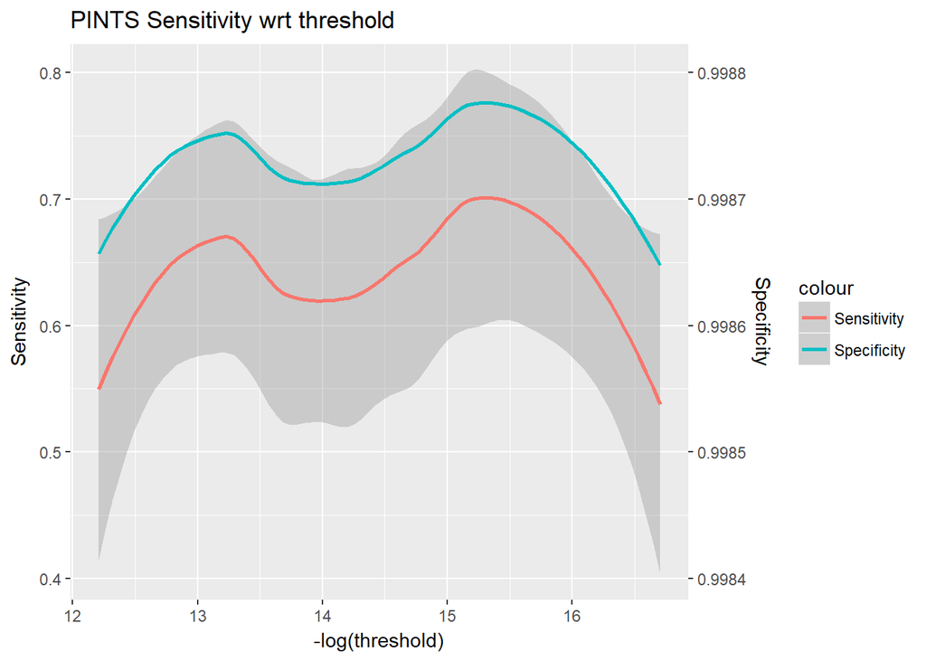

```r
library(ggplot2)

g <- ggplot(final[1:10,], aes(x = -log(threshold)))
g <- g + geom_smooth(aes(y = sensitivity, color = "Sensitivity"))
g <- g + geom_smooth(aes(y = (specificity - .998)*1000-.2, color = "Specificity"), se = FALSE)
g <- g + scale_y_continuous(sec.axis = sec_axis(~./1000 + .998, name = "Specificity"))
g <- g + ggtitle("PINTS Sensitivity wrt threshold") + ylab("Sensitivity")
g
```

A confidence interval is only discplayed for sensitivity, since the specificity ranges over such a small interval that the confidence interval doesn’t really tell us anything meaningful. Either way, the two curves are basically scaled versions of each other. That’s something we’ve learned.

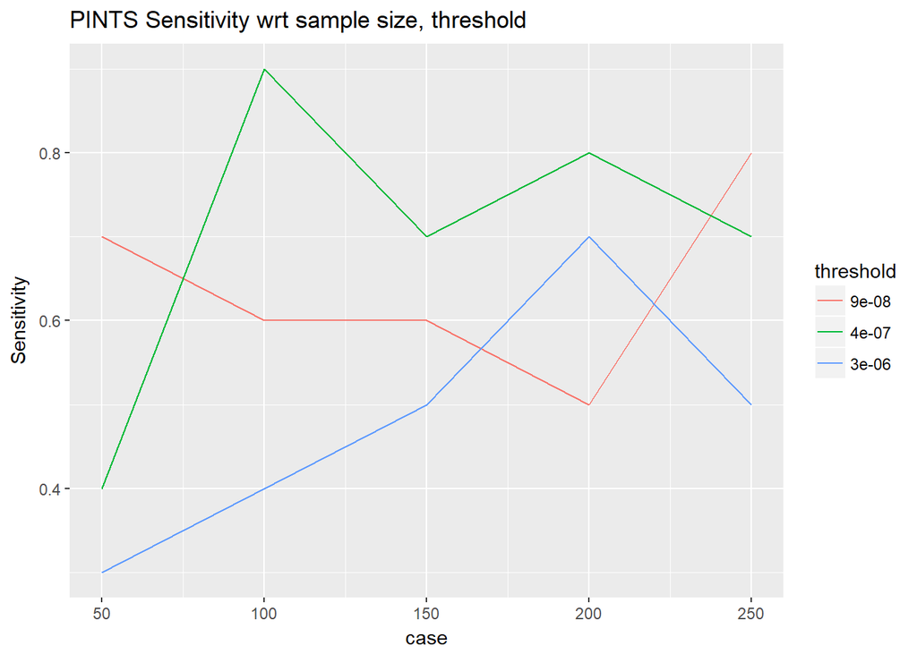

```r
final1 <- read.table("pop_Results_3e6.txt", header = TRUE, sep = ",")
final2 <- read.table("pop_Results_4e7.txt", header = TRUE, sep = ",")
final3 <- read.table("pop_Results_9e8.txt", header = TRUE, sep = ",")

final1$threshold <- 3e-6
final2$threshold <- 4e-7
final3$threshold <- 9e-8

case_final <- rbind(final1, final2, final3)
case_final$threshold <- as.factor(case_final$threshold)

g2 <- ggplot(case_final, aes(x = case))
g2 <- g2 + geom_line(aes(y = sensitivity, color = threshold))
g2 <- g2 + ggtitle("PINTS Sensitivity wrt sample size, threshold") + ylab("Sensitivity")
g2
```